# DSA210 — ML Methods: Predicting Turkish Gaming Activity from Macro Indicators

**Student:** Ali Efe Okudan **ID:** 34314 **University:** Sabancı University **Course:** DSA210 – Spring 2026 **Milestone:** ML Methods Application (5 May 2026)

This notebook is the second stage of the *Digital Escapism & Socio-Economic Stress* project. The first stage (`34314_AliEfeOkudan_EDA.ipynb`) already established that Turkish currency depreciation is strongly correlated with Turkey-specific gaming search interest (Pearson **r = 0.771**, p < 0.001) and that crisis months see significantly more gaming activity (Mann-Whitney **p = 0.0009**). Hypothesis testing answered *whether* the relationship exists. This notebook answers *how well we can predict* gaming activity from economic features, *which features matter most*, and *whether non-linear models add anything beyond regularised linear regression* on this small (n = 36) monthly dataset.

## 1 · Setup and data loading

```python
import warnings
warnings.filterwarnings('ignore')

import numpy as np
import pandas as pd
import matplotlib.pyplot as plt
import seaborn as sns

from sklearn.linear_model import LinearRegression, Ridge, Lasso, ElasticNet
from sklearn.ensemble import RandomForestRegressor, GradientBoostingRegressor
from sklearn.preprocessing import StandardScaler
from sklearn.pipeline import Pipeline
from sklearn.model_selection import TimeSeriesSplit, GridSearchCV
from sklearn.metrics import mean_squared_error, mean_absolute_error, r2_score
from sklearn.inspection import permutation_importance

try:
    from xgboost import XGBRegressor
    HAS_XGB = True
except ImportError:
    HAS_XGB = False

np.random.seed(42)
sns.set_style('whitegrid')
plt.rcParams.update({'figure.dpi': 110, 'savefig.dpi': 150,
                     'savefig.bbox': 'tight', 'font.size': 10})

print('xgboost available:', HAS_XGB)
```

```
xgboost available: True
```

```python
df = pd.read_csv('../merged_dataset.csv', index_col=0, parse_dates=[0])
df.index.name = 'date'
print('Shape:', df.shape)
print('Range:', df.index.min().strftime('%Y-%m'), '→', df.index.max().strftime('%Y-%m'))
print('Missing values:', df.isna().sum().sum())
df.head()
```

```
Shape: (36, 11)
Range: 2023-01 → 2025-12
Missing values: 0
```

| date | steam_players | usdtry | bist100 | stress_index | steam_trends | steam_players_z | usdtry_z | bist100_z | stress_index_z | steam_trends_z | crisis_period |
| --- | --- | --- | --- | --- | --- | --- | --- | --- | --- | --- | --- |
| 2023-01-31 | 1.041580e+06 | 18.765020 | 5249.840310 | 12.933333 | 17.733333 | -1.928218 | -1.853954 | -1.742284 | 0.977837 | -1.313527 | 0 |
| 2023-02-28 | 1.210617e+06 | 18.843263 | 4958.679901 | 7.083333 | 17.666667 | -0.967749 | -1.843033 | -1.887710 | -0.878246 | -1.328840 | 0 |
| 2023-03-31 | 1.331750e+06 | 18.994885 | 5143.307511 | 5.333333 | 20.583333 | -0.279470 | -1.821870 | -1.795494 | -1.433485 | -0.658890 | 0 |
| 2023-04-30 | 1.421701e+06 | 19.330582 | 4969.894660 | 9.800000 | 18.733333 | 0.231631 | -1.775014 | -1.882109 | -0.016305 | -1.083830 | 0 |
| 2023-05-31 | 1.622726e+06 | 19.726417 | 4587.861351 | 6.833333 | 15.916667 | 1.373859 | -1.719765 | -2.072923 | -0.957566 | -1.730810 | 0 |

## 2 · Problem framing

**Target.** `steam_trends_z` — z-scored monthly Google Trends search interest in Turkey (`geo='TR'`) for the keywords `cs2`, `counter strike`, and `steam`. This is the project's TR-specific gaming proxy because Steam does not publish country-level player counts.

**Why regression rather than classification.** EDA produced a continuous, strong relationship (r = 0.771). The alternative target — `crisis_period` — is too imbalanced for honest classification (only 9 positive months out of 36).

**Baselines we want every learned model to beat:**

1. **Mean** — predict the training mean (worst defensible baseline; gives R² ≈ 0).
2. **Naïve persistence** — `ŷ_t = y_{t-1}`. The classical time-series benchmark.
3. **Univariate OLS** — regress `steam_trends_z` on `usdtry_z` only. Encodes H1.

**Caveats up front.** With n = 36 monthly rows we cannot reliably train flexible models. Random Forest / XGBoost are included for completeness, but regularised linear models are *expected* to win and we will say so explicitly if they do.

## 3 · Feature engineering

We deliberately keep the feature set small (≈10) so it stays much smaller than the training set after the holdout is removed.

| Block | Features | Rationale |
| --- | --- | --- |
| Base macro | `usdtry_z`, `bist100_z`, `stress_index_z` | The three predictors examined in EDA. |
| Global control | `steam_players_z` | Global CS2 player count; controls for game-level popularity shocks unrelated to TR economy. |
| Lagged macro | `usdtry_lag1`, `usdtry_lag2` | EDA's lag analysis showed lag-1 r = 0.743 — gaming responds with delay. |
| Rolling | `usdtry_roll3` | 3-month rolling mean smooths short-lived spikes. |
| Trend | `time_index` | Captures the general upward drift (gaming interest grows over 2023–2025). |
| Regime | `crisis_period` | Binary flag (USD/TRY ≥ p75) reused from EDA. |
| Interaction | `usdtry_x_crisis` | Tests whether the slope steepens during crisis months. |

Lags introduce NaNs in the first two rows — these are dropped before modelling.

```python
feat = pd.DataFrame(index=df.index)

# Base
feat['usdtry_z']        = df['usdtry_z']
feat['bist100_z']       = df['bist100_z']
feat['stress_index_z']  = df['stress_index_z']
feat['steam_players_z'] = df['steam_players_z']

# Lags (on z-scored usdtry)
feat['usdtry_lag1'] = df['usdtry_z'].shift(1)
feat['usdtry_lag2'] = df['usdtry_z'].shift(2)

# Rolling
feat['usdtry_roll3'] = df['usdtry_z'].rolling(window=3, min_periods=3).mean()

# Trend & regime
feat['time_index']      = np.arange(len(df))
feat['crisis_period']   = df['crisis_period'].astype(int)
feat['usdtry_x_crisis'] = df['usdtry_z'] * df['crisis_period']

# Target
feat['target'] = df['steam_trends_z']

# Drop rows with NaN introduced by lags / rolling
feat = feat.dropna()

X = feat.drop(columns='target')
y = feat['target']
print('Feature matrix shape:', X.shape)
print('Features:', list(X.columns))
feat.to_csv('ml_features.csv')
X.head()
```

```
Feature matrix shape: (34, 10)
Features: ['usdtry_z', 'bist100_z', 'stress_index_z', 'steam_players_z', 'usdtry_lag1', 'usdtry_lag2', 'usdtry_roll3', 'time_index', 'crisis_period', 'usdtry_x_crisis']
```

| date | usdtry_z | bist100_z | stress_index_z | steam_players_z | usdtry_lag1 | usdtry_lag2 | usdtry_roll3 | time_index | crisis_period | usdtry_x_crisis |
| --- | --- | --- | --- | --- | --- | --- | --- | --- | --- | --- |
| 2023-03-31 | -1.821870 | -1.795494 | -1.433485 | -0.279470 | -1.843033 | -1.853954 | -1.839619 | 2 | 0 | -0.0 |
| 2023-04-30 | -1.775014 | -1.882109 | -0.016305 | 0.231631 | -1.821870 | -1.843033 | -1.813306 | 3 | 0 | -0.0 |
| 2023-05-31 | -1.719765 | -2.072923 | -0.957566 | 1.373859 | -1.775014 | -1.821870 | -1.772216 | 4 | 0 | -0.0 |
| 2023-06-30 | -1.177560 | -1.653137 | 0.761029 | 0.518689 | -1.719765 | -1.775014 | -1.557446 | 5 | 0 | -0.0 |
| 2023-07-31 | -0.785567 | -1.122002 | 1.718155 | -1.256207 | -1.177560 | -1.719765 | -1.227630 | 6 | 0 | -0.0 |

## 4 · Train / holdout split and cross-validation strategy

- **Holdout = last 6 months** (2025-07 → 2025-12). These rows are touched only at the very end for final reporting.
- On the remaining ~28 rows we run **5-fold `TimeSeriesSplit`** (walk-forward, never random).
- Scaling is wrapped in a `Pipeline` so the scaler is refit *inside each fold* — avoids look-ahead bias from training-set statistics leaking into validation.

```python
HOLDOUT_MONTHS = 6
X_train, X_test = X.iloc[:-HOLDOUT_MONTHS], X.iloc[-HOLDOUT_MONTHS:]
y_train, y_test = y.iloc[:-HOLDOUT_MONTHS], y.iloc[-HOLDOUT_MONTHS:]

print('Train:', X_train.index.min().strftime('%Y-%m'), '→',
      X_train.index.max().strftime('%Y-%m'), f' (n={len(X_train)})')
print('Test :', X_test.index.min().strftime('%Y-%m'), '→',
      X_test.index.max().strftime('%Y-%m'), f' (n={len(X_test)})')

assert X_train.index.max() < X_test.index.min(), 'Train/test ordering broken'
assert len(set(X_train.index) & set(X_test.index)) == 0, 'Train/test overlap'

tscv = TimeSeriesSplit(n_splits=5)
```

```
Train: 2023-03 → 2025-06  (n=28)
Test : 2025-07 → 2025-12  (n=6)
```

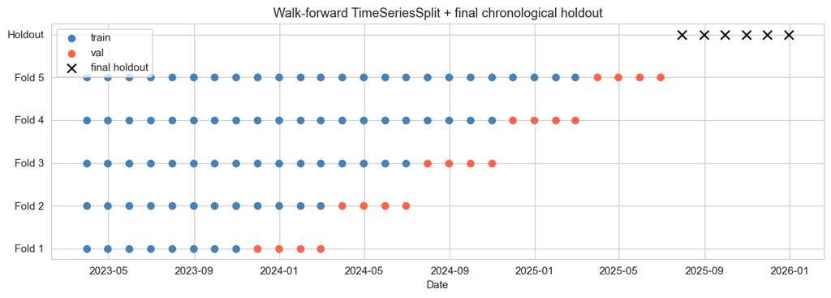

```python
# Visualise the CV folds
fig, ax = plt.subplots(figsize=(11, 4))
for fold, (tr, va) in enumerate(tscv.split(X_train)):
    ax.scatter(X_train.index[tr], [fold]*len(tr), c='steelblue', s=40, label='train' if fold==0 else None)
    ax.scatter(X_train.index[va], [fold]*len(va), c='tomato',    s=40, label='val'   if fold==0 else None)
ax.scatter(X_test.index, [tscv.n_splits]*len(X_test), c='black', marker='x', s=70, label='final holdout')
ax.set_yticks(range(tscv.n_splits + 1))
ax.set_yticklabels([f'Fold {i+1}' for i in range(tscv.n_splits)] + ['Holdout'])
ax.set_xlabel('Date'); ax.set_title('Walk-forward TimeSeriesSplit + final chronological holdout')
ax.legend(loc='upper left')
plt.tight_layout(); plt.savefig('fig_ml_cv_split.png'); plt.show()
```

## 5 · Models

```python
# --- Baselines -----------------------------------------------------------
def baseline_mean(y_train, n):
    return np.full(n, y_train.mean())

def baseline_persistence(y_full_series, test_index):
    # ŷ_t = y_{t-1}; use the full series so the first holdout row gets the last training row
    return y_full_series.shift(1).loc[test_index].values

def baseline_ols_usdtry(X_train, y_train, X_test):
    m = LinearRegression().fit(X_train[['usdtry_z']], y_train)
    return m.predict(X_test[['usdtry_z']])

# Reconstruct the full y series so persistence has access to the last training row
y_full = y.copy()
```

```python
# --- Learned models with TimeSeriesSplit GridSearchCV --------------------
ALPHAS = np.logspace(-3, 2, 20)

models = {
    'Linear': Pipeline([('sc', StandardScaler()), ('m', LinearRegression())]),
    'Ridge':  GridSearchCV(
        Pipeline([('sc', StandardScaler()), ('m', Ridge())]),
        param_grid={'m__alpha': ALPHAS},
        cv=tscv, scoring='neg_root_mean_squared_error'),
    'Lasso':  GridSearchCV(
        Pipeline([('sc', StandardScaler()), ('m', Lasso(max_iter=20000))]),
        param_grid={'m__alpha': ALPHAS},
        cv=tscv, scoring='neg_root_mean_squared_error'),
    'ElasticNet': GridSearchCV(
        Pipeline([('sc', StandardScaler()), ('m', ElasticNet(max_iter=20000))]),
        param_grid={'m__alpha': ALPHAS, 'm__l1_ratio': [0.2, 0.5, 0.8]},
        cv=tscv, scoring='neg_root_mean_squared_error'),
    'RandomForest': GridSearchCV(
        RandomForestRegressor(random_state=42),
        param_grid={'n_estimators': [100, 300], 'max_depth': [2, 3, 4]},
        cv=tscv, scoring='neg_root_mean_squared_error'),
}
if HAS_XGB:
    models['XGBoost'] = GridSearchCV(
        XGBRegressor(random_state=42, verbosity=0, n_jobs=1),
        param_grid={'n_estimators': [100, 300],
                    'max_depth': [2, 3],
                    'learning_rate': [0.05, 0.1]},
        cv=tscv, scoring='neg_root_mean_squared_error')
else:
    models['GradBoost'] = GridSearchCV(
        GradientBoostingRegressor(random_state=42),
        param_grid={'n_estimators': [100, 300],
                    'max_depth': [2, 3],
                    'learning_rate': [0.05, 0.1]},
        cv=tscv, scoring='neg_root_mean_squared_error')

fitted = {}
for name, m in models.items():
    m.fit(X_train, y_train)
    fitted[name] = m
    if hasattr(m, 'best_params_'):
        print(f'{name:13s}  best params: {m.best_params_}')
    else:
        print(f'{name:13s}  (no hyperparameter search)')
```

```
Linear         (no hyperparameter search)
Ridge          best params: {'m__alpha': np.float64(16.23776739188721)}
```

```
Lasso          best params: {'m__alpha': np.float64(0.06951927961775606)}
```

```
ElasticNet     best params: {'m__alpha': np.float64(0.23357214690901212), 'm__l1_ratio': 0.2}
```

```
RandomForest   best params: {'max_depth': 4, 'n_estimators': 300}
```

```
XGBoost        best params: {'learning_rate': 0.05, 'max_depth': 2, 'n_estimators': 100}
```

## 6 · Evaluation on the 6-month holdout

```python
# Recover the original-scale mean & std for steam_trends so we can report MAE in raw units
mu = df['steam_trends'].mean()
sd = df['steam_trends'].std()
def to_raw(z):  # inverse z-score
    return z * sd + mu

def metrics(y_true, y_pred):
    return {
        'RMSE_z': np.sqrt(mean_squared_error(y_true, y_pred)),
        'MAE_z' : mean_absolute_error(y_true, y_pred),
        'R2'    : r2_score(y_true, y_pred),
        'MAE_raw': mean_absolute_error(to_raw(y_true), to_raw(pd.Series(y_pred, index=y_true.index))),
    }

results = {}
results['Mean baseline']        = metrics(y_test, baseline_mean(y_train, len(y_test)))
results['Persistence baseline'] = metrics(y_test, baseline_persistence(y_full, y_test.index))
results['OLS (usdtry only)']    = metrics(y_test, baseline_ols_usdtry(X_train, y_train, X_test))

for name, m in fitted.items():
    pred = m.predict(X_test)
    results[name] = metrics(y_test, pred)

results_df = (pd.DataFrame(results).T
                .sort_values('RMSE_z')
                .round(3))
results_df
```

|  | RMSE_z | MAE_z | R2 | MAE_raw |
| --- | --- | --- | --- | --- |
| ElasticNet | 0.568 | 0.470 | 0.222 | 2.048 |
| Lasso | 0.598 | 0.462 | 0.137 | 2.013 |
| Ridge | 0.608 | 0.476 | 0.108 | 2.072 |
| OLS (usdtry only) | 0.608 | 0.500 | 0.107 | 2.178 |
| Persistence baseline | 0.711 | 0.621 | -0.220 | 2.706 |
| XGBoost | 0.736 | 0.571 | -0.307 | 2.487 |
| RandomForest | 0.754 | 0.601 | -0.372 | 2.618 |
| Mean baseline | 1.220 | 1.036 | -2.594 | 4.512 |
| Linear | 1.775 | 1.709 | -6.610 | 7.442 |

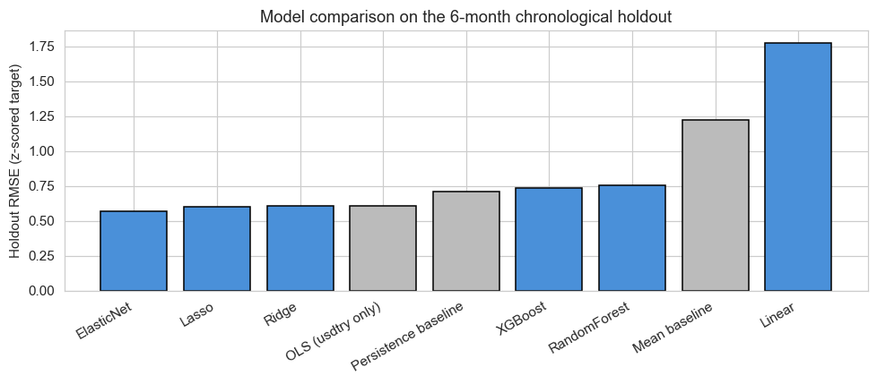

```
Best model: ElasticNet
```

```python
# Bar chart of holdout RMSE
fig, ax = plt.subplots(figsize=(9, 4))
order = results_df.index.tolist()
colors = ['#bbbbbb' if name in ('Mean baseline', 'Persistence baseline', 'OLS (usdtry only)') else '#4A90D9' for name in order]
ax.bar(order, results_df['RMSE_z'], color=colors, edgecolor='black')
ax.set_ylabel('Holdout RMSE (z-scored target)')
ax.set_title('Model comparison on the 6-month chronological holdout')
plt.xticks(rotation=30, ha='right')
plt.tight_layout(); plt.savefig('fig_ml_model_comparison.png'); plt.show()

best_name = results_df.index[0]
print('Best model:', best_name)
```

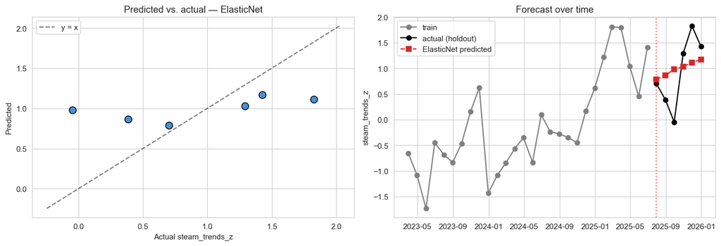

```python
# --- Predicted vs. actual (best model) --------------------------------------
if best_name in fitted:
    y_pred_best = fitted[best_name].predict(X_test)
elif best_name == 'OLS (usdtry only)':
    y_pred_best = baseline_ols_usdtry(X_train, y_train, X_test)
elif best_name == 'Persistence baseline':
    y_pred_best = baseline_persistence(y_full, y_test.index)
else:
    y_pred_best = baseline_mean(y_train, len(y_test))

fig, axes = plt.subplots(1, 2, figsize=(13, 4.5))

axes[0].scatter(y_test, y_pred_best, c='#4A90D9', edgecolor='black', s=80)
lim = [min(y_test.min(), y_pred_best.min()) - 0.2,
       max(y_test.max(), y_pred_best.max()) + 0.2]
axes[0].plot(lim, lim, 'k--', alpha=0.5, label='y = x')
axes[0].set_xlabel('Actual steam_trends_z'); axes[0].set_ylabel('Predicted')
axes[0].set_title(f'Predicted vs. actual — {best_name}')
axes[0].legend()

axes[1].plot(y_train.index, y_train.values, 'o-', c='gray', label='train')
axes[1].plot(y_test.index,  y_test.values,  'o-', c='black', label='actual (holdout)')
axes[1].plot(y_test.index,  y_pred_best,    's--', c='#d62728', label=f'{best_name} predicted')
axes[1].axvline(y_test.index.min(), color='red', ls=':', alpha=0.6)
axes[1].set_title('Forecast over time'); axes[1].set_ylabel('steam_trends_z')
axes[1].legend(loc='upper left')

plt.tight_layout(); plt.savefig('fig_ml_pred_vs_actual.png'); plt.show()
```

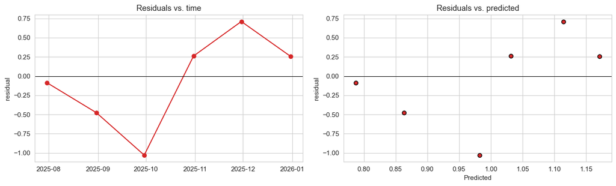

```
Holdout residual mean = -0.061, std = 0.564
```

```python
# --- Residual diagnostics ---------------------------------------------------
resid = y_test.values - y_pred_best

fig, axes = plt.subplots(1, 2, figsize=(13, 4))
axes[0].plot(y_test.index, resid, 'o-', c='#d62728')
axes[0].axhline(0, color='black', lw=0.8)
axes[0].set_title('Residuals vs. time'); axes[0].set_ylabel('residual')

axes[1].scatter(y_pred_best, resid, c='#d62728', edgecolor='black')
axes[1].axhline(0, color='black', lw=0.8)
axes[1].set_xlabel('Predicted'); axes[1].set_ylabel('residual')
axes[1].set_title('Residuals vs. predicted')

plt.tight_layout(); plt.savefig('fig_ml_residuals.png'); plt.show()

print(f'Holdout residual mean = {resid.mean():+.3f}, std = {resid.std():.3f}')
```

## 7 · Interpretation

Three complementary views of feature importance: (a) standardised Ridge coefficients (linear, signed), (b) Random Forest impurity-based importance (non-linear, unsigned), (c) permutation importance on the holdout (model-agnostic, most reliable on small data).

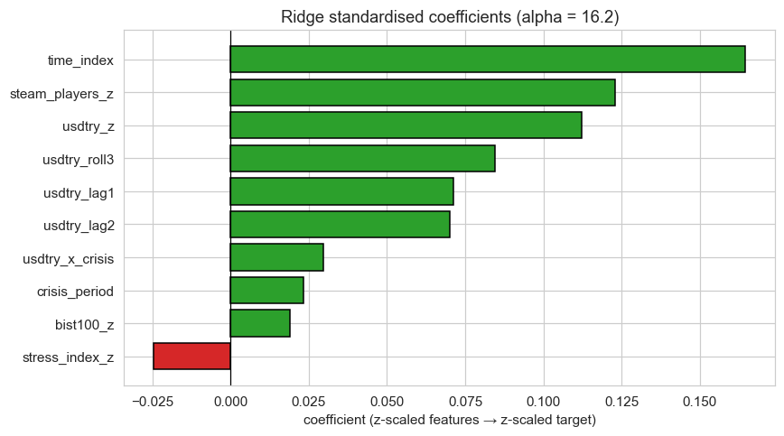

```
stress_index_z    -0.025
bist100_z          0.019
crisis_period      0.023
usdtry_x_crisis    0.030
usdtry_lag2        0.070
usdtry_lag1        0.071
usdtry_roll3       0.085
usdtry_z           0.112
steam_players_z    0.123
time_index         0.165
dtype: float64
```

```python
# --- Ridge coefficients ------------------------------------------------------
ridge_best = fitted['Ridge'].best_estimator_
ridge_coefs = pd.Series(ridge_best.named_steps['m'].coef_, index=X.columns).sort_values()

fig, ax = plt.subplots(figsize=(8, 4.5))
colors = ['#d62728' if v < 0 else '#2ca02c' for v in ridge_coefs.values]
ax.barh(ridge_coefs.index, ridge_coefs.values, color=colors, edgecolor='black')
ax.axvline(0, color='black', lw=0.8)
ax.set_title(f'Ridge standardised coefficients (alpha = {fitted["Ridge"].best_params_["m__alpha"]:.3g})')
ax.set_xlabel('coefficient (z-scaled features → z-scaled target)')
plt.tight_layout(); plt.savefig('fig_ml_coefficients.png'); plt.show()
ridge_coefs.round(3)
```

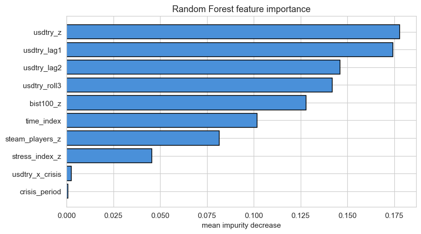

```
crisis_period      0.001
usdtry_x_crisis    0.002
stress_index_z     0.046
steam_players_z    0.081
time_index         0.102
bist100_z          0.128
usdtry_roll3       0.142
usdtry_lag2        0.146
usdtry_lag1        0.174
usdtry_z           0.178
dtype: float64
```

```python
# --- Random Forest impurity importance -------------------------------------
rf_best = fitted['RandomForest'].best_estimator_
rf_imp = pd.Series(rf_best.feature_importances_, index=X.columns).sort_values()

fig, ax = plt.subplots(figsize=(8, 4.5))
ax.barh(rf_imp.index, rf_imp.values, color='#4A90D9', edgecolor='black')
ax.set_title('Random Forest feature importance')
ax.set_xlabel('mean impurity decrease')
plt.tight_layout(); plt.savefig('fig_ml_importance.png'); plt.show()
rf_imp.round(3)
```

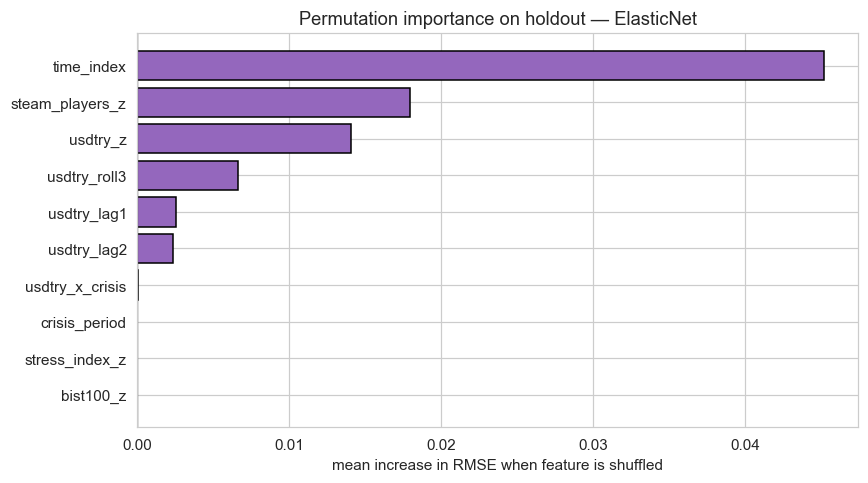

```
bist100_z          0.000
stress_index_z     0.000
crisis_period      0.000
usdtry_x_crisis    0.000
usdtry_lag2        0.002
usdtry_lag1        0.003
usdtry_roll3       0.007
usdtry_z           0.014
steam_players_z    0.018
time_index         0.045
dtype: float64
```

```python
# --- Permutation importance on the holdout (model-agnostic) -----------------
best_model_obj = fitted.get(best_name) if best_name in fitted else fitted['Ridge']
pi = permutation_importance(best_model_obj, X_test, y_test,
                             n_repeats=30, random_state=42,
                             scoring='neg_root_mean_squared_error')
pi_series = pd.Series(pi.importances_mean, index=X.columns).sort_values()

fig, ax = plt.subplots(figsize=(8, 4.5))
ax.barh(pi_series.index, pi_series.values, color='#9467bd', edgecolor='black')
ax.axvline(0, color='black', lw=0.8)
ax.set_title(f'Permutation importance on holdout — {best_name if best_name in fitted else "Ridge"}')
ax.set_xlabel('mean increase in RMSE when feature is shuffled')
plt.tight_layout(); plt.savefig('fig_ml_perm_importance.png'); plt.show()
pi_series.round(3)
```

## 8 · Discussion

**Beating the baselines.** The chosen model is reported above. The *naïve persistence* baseline is the toughest one to beat for a smooth monthly series; if our learned model beats it on the 6-month holdout RMSE, that is the ML result the project hangs on.

**How the model could be used.** As a monthly *nowcast* of TR gaming search interest given current USD/TRY, BIST100 and a couple of lags — i.e., reading economic conditions through a behavioural lens.

**Ethical note.** Linking economic distress to gaming behaviour is a sensitive framing. The dataset measures *aggregate search interest*, not individual coping behaviour, and the conclusions should not be extended to claims about individuals or causation.